# Lecture 12 Exercise — Support Vector Machines

PubH 6010 Independent Study · Searcy & Boehm (2022): forecasting E. coli exceedances at Cowell Beach

Katie O’Brien

2026-11-15

# 1 Overview

Lecture 12 covers the **maximal margin classifier**, the **support vector classifier** (linear kernel) and the **support vector machine** with **polynomial** and **radial** kernels. This week’s paper compares four classifiers, an SVM among them, for forecasting whether a beach water sample will exceed California’s fecal indicator bacteria (FIB) standard up to three days ahead. It is a small-scale version of the early-warning question in your project: can environmental data available today predict a water-quality hazard tomorrow?

> Searcy RT, Boehm AB. Know Before You Go: Data-Driven Beach Water Quality Forecasting. *Environmental Science & Technology* (2022). doi:[10.1021/acs.est.2c05972](https://doi.org/10.1021/acs.est.2c05972). Free copy and Supporting Information (SI): [NOAA repository](https://repository.library.noaa.gov/view/noaa/56907).

The data are on the Stanford Digital Repository, doi:[10.25740/nw799cp6263](https://doi.org/10.25740/nw799cp6263) (CC BY). The authors’ Python code is at github.com/rtsearcy/wq-forecasting.

**Reading before you start.**

- Read the Abstract, Introduction and Methods.
- In the SI, read the **Tuning Case Study** (p. S3) and Tables **S3, S5, S6, S7 and S8**. We compare with these tables.

**What we take from the paper.** The paper fits about 400 forecast models: 2 beaches × 2 FIB types × 8 train/test partitions × 3 lead times × 4 model types. We take **one slice** of it and fit **three SVMs** on it:

[output not shown]

**Comparing with the paper.** The paper does not report results for single slices. It reports **medians across many models**. For all SVM models (Table S7) the medians are sensitivity 0.00, specificity 1.00 and AUC 0.56. For Cowell *E. coli* across all model types (Table S8) they are 0.12, 0.91 and 0.58. After cutoff tuning (SI p. S3) the SVM medians are sensitivity 0.32 and specificity 0.78. So the comparison is “is my slice inside the paper’s range, and why or why not?”, not an exact match as in Week 11.

**Code: slides vs here.** As in previous weeks we use tidymodels where the slides use `caret`. The engine is the slides’ `kernlab::ksvm()`.

| slides | here |
| --- | --- |
| `ksvm(AHD ~ ., kernel = "vanilladot", C = 10)` | `svm_linear(cost = 10) \|> set_engine("kernlab")` |
| `kernel = "polydot", kpar = list(degree, scale, offset)` | `svm_poly(cost, degree, scale_factor)` (offset fixed at 1) |
| `kernel = "rbfdot", kpar = list(sigma)` | `svm_rbf(cost, rbf_sigma)` |
| `train(method = "svmLinear", tuneGrid, trControl = trainControl("cv", number = 10))` | `tune_grid(..., resamples = vfold_cv(train, v = 10, strata = exc))` |
| `svm_fit@SVindex`, `nSV(svm_fit)` | `extract_fit_engine(fit) \|> nSV()` |
| `ksvm` scales predictors internally (`scaled = TRUE`) | `step_normalize()` in a recipe, so the scaling is explicit and uses training means and SDs |

**Install once:** `install.packages(c("tidymodels", "kernlab"))`.

# 2 Data

`cowell_ec_lead1.csv` has 384 samples × 15 columns. It was built from the authors’ `CB_bulk_dataset.csv` (also in this folder) by `raw/prepare_cowell_slice.py`, which copies the paper’s own data-cleaning code. So the samples are exactly those in the paper’s partition.

| column | meaning |
| --- | --- |
| `date`, `year` | sampling date (April–October each year) |
| `split` | `train` (2007–2012) or `test` (2013–2014) |
| `EC`, `EC_exc` | *E. coli* (CFU/100 mL); 1 if `EC` > 400, the California single-sample standard |
| `lograin6` | log10 rainfall on the 6th day before sampling |
| `logflow4` | log10 mean daily San Lorenzo River discharge, 4 days before |
| `WVHT4` | significant wave height (m), 4 days before |
| `APD2`–`APD5` | average wave period (s), 2–5 days before |
| `tide_max4` | predicted daily maximum tide level (m), 4 days before |
| `rad4` | mean daily solar irradiance (W/m²), 4 days before |
| `atemp_min5` | daily minimum air temperature (°C), 5 days before |

The number in each name is the number of **days before the sampling day** (SI Tables S2.1–S2.5). Every predictor has a lag of at least 2 days, so all of them would be known when a forecast is issued the day before sampling.

Submit your knitted `.Rmd` with short written answers to the questions in **bold**.

# 3 Tasks

## 3.1 Part A — The data

1. Count the samples and exceedances in the training and test sets, and check them against SI Table S5 (Cowell, EC, first row). Tabulate the exceedance rate by year. What test accuracy does “always predict no exceedance” achieve?

```r
library(tidyverse)
library(tidymodels)
library(kernlab)
tidymodels_prefer()

cb <- read_csv("cowell_ec_lead1.csv") |>
  mutate(exc = factor(if_else(EC_exc == 1, "yes", "no"), levels = c("yes", "no")))
predictors <- c("lograin6", "logflow4", "WVHT4", "APD2", "APD3", "APD4", "APD5",
                "tide_max4", "rad4", "atemp_min5")
train <- cb |> filter(split == "train") |> select(exc, all_of(predictors))
test  <- cb |> filter(split == "test")  |> select(exc, all_of(predictors))

# the paper's class_weight = 'balanced': n / (2 * n_class)
w_bal <- c(yes = nrow(train) / (2 * sum(train$exc == "yes")),
           no  = nrow(train) / (2 * sum(train$exc == "no")))

rec <- recipe(exc ~ ., data = train) |> step_normalize(all_predictors())

# ---- helpers -----------------------------------------------------------------
# SVM decision value f(x), oriented so that larger = more likely "yes".
# (kernlab's decision value is positive for the 2nd factor level, "no", so we flip it.)
svm_score <- function(wf_fit, new_data) {
  x <- extract_recipe(wf_fit) |> bake(new_data = new_data, all_predictors())
  -as.numeric(predict(extract_fit_engine(wf_fit), x, type = "decision"))
}
# linear kernel only: coefficient vector beta (standardized scale), positive = toward "yes"
svm_w <- function(wf_fit) {
  m <- extract_fit_engine(wf_fit)
  -colSums(coef(m)[[1]] * xmatrix(m)[[1]])
}
# prob.model = FALSE: no Platt probabilities (see Part D), so predict() returns classes only
lin_fit <- function(C, weights = NULL, data = train) {
  spec <- svm_linear(cost = C) |>
    set_engine("kernlab", class.weights = weights, prob.model = FALSE) |>
    set_mode("classification")
  workflow(rec, spec) |> fit(data)
}

# counting exceedances in training and testing sets
train %>%
  count(exc == "yes")
```

```
## # A tibble: 2 × 2
##   `exc == "yes"`     n
##   <lgl>          <int>
## 1 FALSE            205
## 2 TRUE              85
```

```r
test %>%
  count(exc == "yes")
```

```
## # A tibble: 2 × 2
##   `exc == "yes"`     n
##   <lgl>          <int>
## 1 FALSE             74
## 2 TRUE              20
```

```r
# calculating exceedance rate by year
cb %>%
  group_by(year) %>%
  summarize(
    total_samples = n(),
    exceedances = sum(exc == "yes"),
    exceedance_rate = mean(exc == "yes")
  )
```

```
## # A tibble: 8 × 4
##    year total_samples exceedances exceedance_rate
##   <dbl>         <int>       <int>           <dbl>
## 1  2007            43           8           0.186
## 2  2008            63          18           0.286
## 3  2009            57          23           0.404
## 4  2010            43          12           0.279
## 5  2011            43          12           0.279
## 6  2012            41          12           0.293
## 7  2013            45           5           0.111
## 8  2014            49          15           0.306
```

The counts of exceedances in the training and testing sets match table S5. “Always predict no exceedance” would achieve a test accuracy of ~78% because there is a ~22% exceedance rate in the test set.

2. Report the mean and SD of each predictor in the training set. What share of samples had any rain 6 days before sampling (`lograin6 > 0`), and what is the exceedance rate with and without it?

```r
# mean and SD of all predictors
train %>%
  summarize(
    across(
      .cols = where(is.numeric) & !any_of(c("year", "exc")),
      .fns = list(
        mean = ~mean(.x, na.rm = TRUE),
        sd = ~sd(.x, na.rm = TRUE)
      ),
      .names = "{.col}_{.fn}"
    )
  )
```

```
## # A tibble: 1 × 20
##   lograin6_mean lograin6_sd logflow4_mean logflow4_sd WVHT4_mean WVHT4_sd
##           <dbl>       <dbl>         <dbl>       <dbl>      <dbl>    <dbl>
## 1        0.0508       0.208          1.15       0.551       1.33    0.556
## # ℹ 14 more variables: APD2_mean <dbl>, APD2_sd <dbl>, APD3_mean <dbl>,
## #   APD3_sd <dbl>, APD4_mean <dbl>, APD4_sd <dbl>, APD5_mean <dbl>,
## #   APD5_sd <dbl>, tide_max4_mean <dbl>, tide_max4_sd <dbl>, rad4_mean <dbl>,
## #   rad4_sd <dbl>, atemp_min5_mean <dbl>, atemp_min5_sd <dbl>
```

```r
# number of samples with lograin6 > 0
train %>%
  filter(lograin6 > 0 ) %>%
  summarise(n())
```

```
## # A tibble: 1 × 1
##   `n()`
##   <int>
## 1    28
```

```r
# exceedance rate with and without lograin6 > 0 in training set
train %>%
  group_by(lograin6 > 0) %>%
  summarize(exceedance_rate = mean(exc == "yes"))
```

```
## # A tibble: 2 × 2
##   `lograin6 > 0` exceedance_rate
##   <lgl>                    <dbl>
## 1 FALSE                    0.294
## 2 TRUE                     0.286
```

28 samples in the training set had rain 6 days before sampling. The exceedance rate in samples with rain in the past six days was 28.5%, vs 29.3%.

> **Q1.** Do your counts match Table S5? Describe how the exceedance rate changes over the years, and why that matters for a model trained on 2007–2012 (see SI p. S2 on changes at Cowell Beach). What is the accuracy baseline? Using the kernel formulas on the slides, explain why SVM predictors must be put on a common scale, and which predictor would dominate if they were not.

## 3.2 Part B — The support vector classifier (linear kernel)

3. Fit a linear SVM **without class weights** for C ∈ {0.01, 1, 100} using `lin_fit()` (starter code). For each, report the number of support vectors, the size of the coefficient vector ‖β‖ (`svm_w()`), and how many training samples are predicted “yes”.

```r
# ---- Part B ------------------------------------------------------------------
f <- lin_fit(1)                                       # unweighted
nSV(extract_fit_engine(f))
```

```
## [1] 205
```

```r
sqrt(sum(svm_w(f)^2))
```

```
## [1] 0.0002303904
```

```r
table(predict(f, train)$.pred_class)
```

```
##
## yes  no
##   0 290
```

There are 205 support vectors. The size of the coefficient vector is 0.00023. No training samples are predicted yes.

4. Refit with `weights = w_bal` (the paper’s balanced weights) for C ∈ {0.01, 0.1, 1, 10, 100}. Report the same columns plus training sensitivity and specificity. Print the coefficient vector `svm_w()` at C = 1.

```r
lin_spec <- svm_linear(cost = tune()) |>
  set_engine("kernlab", class.weights = w_bal, prob.model = FALSE) |>
  set_mode("classification")

c_vals <- c(0.01, 0.1, 1, 10, 100)

# refitting
fits <- map(c_vals, ~ lin_fit(C = .x, weights = w_bal, data = train))
names(fits) <- as.character(c_vals)

# summary table
bal_results <- map2_dfr(fits, c_vals, function(f, c_val) {
  preds <- bind_cols(
    train |> select(exc),
    predict(f, train)
  )

  tibble(
    C = c_val,
    nSV = nSV(extract_fit_engine(f)),
    w_norm = sqrt(sum(svm_w(f)^2)),
    pred_no = sum(preds$.pred_class == "no"),
    pred_yes = sum(preds$.pred_class == "yes"),
    train_sens = sens(preds, truth = exc, estimate = .pred_class)$.estimate,
    train_spec = spec(preds, truth = exc, estimate = .pred_class)$.estimate
  )
})

print(bal_results)
```

```
## # A tibble: 5 × 7
##        C   nSV w_norm pred_no pred_yes train_sens train_spec
##    <dbl> <int>  <dbl>   <int>    <int>      <dbl>      <dbl>
## 1   0.01   259  0.559     117      173      0.8        0.488
## 2   0.1    228  0.852     149      141      0.718      0.610
## 3   1      221  0.967     147      143      0.729      0.605
## 4  10      221  0.967     147      143      0.729      0.605
## 5 100      221  0.967     147      143      0.729      0.605
```

```r
# coefficient vector at C = 1
svm_w(fits[["1"]])
```

```
##    lograin6    logflow4       WVHT4        APD2        APD3        APD4
##  0.34594286 -0.07240394  0.03808531 -0.35408062 -0.56273461 -0.13154354
##        APD5   tide_max4        rad4  atemp_min5
##  0.24254726  0.42131469  0.09462232  0.32242419
```

5. Tune C ∈ {0.001, …, 100} with class weights by 10-fold stratified CV, using **balanced accuracy** (the paper’s tuning metric). Plot the CV results.

```r
set.seed(1234)
folds <- vfold_cv(train, v = 10, strata = exc)        # reuse these folds in Parts C and D
cv_metrics <- metric_set(bal_accuracy, sensitivity, specificity)
lin_res <- tune_grid(workflow(rec, lin_spec), resamples = folds,
                     grid = tibble(cost = 10^(-3:2)), metrics = cv_metrics)
collect_metrics(lin_res)
```

```
## # A tibble: 18 × 7
##       cost .metric      .estimator  mean     n std_err .config
##      <dbl> <chr>        <chr>      <dbl> <int>   <dbl> <chr>
##  1   0.001 bal_accuracy binary     0.487    10 0.00594 pre0_mod1_post0
##  2   0.001 sensitivity  binary     0.522    10 0.161   pre0_mod1_post0
##  3   0.001 specificity  binary     0.452    10 0.153   pre0_mod1_post0
##  4   0.01  bal_accuracy binary     0.614    10 0.0315  pre0_mod2_post0
##  5   0.01  sensitivity  binary     0.761    10 0.0541  pre0_mod2_post0
##  6   0.01  specificity  binary     0.467    10 0.0359  pre0_mod2_post0
##  7   0.1   bal_accuracy binary     0.633    10 0.0394  pre0_mod3_post0
##  8   0.1   sensitivity  binary     0.690    10 0.0778  pre0_mod3_post0
##  9   0.1   specificity  binary     0.575    10 0.0456  pre0_mod3_post0
## 10   1     bal_accuracy binary     0.636    10 0.0423  pre0_mod4_post0
## 11   1     sensitivity  binary     0.678    10 0.0904  pre0_mod4_post0
## 12   1     specificity  binary     0.595    10 0.0439  pre0_mod4_post0
## 13  10     bal_accuracy binary     0.642    10 0.0388  pre0_mod5_post0
## 14  10     sensitivity  binary     0.690    10 0.0845  pre0_mod5_post0
## 15  10     specificity  binary     0.595    10 0.0439  pre0_mod5_post0
## 16 100     bal_accuracy binary     0.642    10 0.0388  pre0_mod6_post0
## 17 100     sensitivity  binary     0.690    10 0.0845  pre0_mod6_post0
## 18 100     specificity  binary     0.595    10 0.0439  pre0_mod6_post0
```

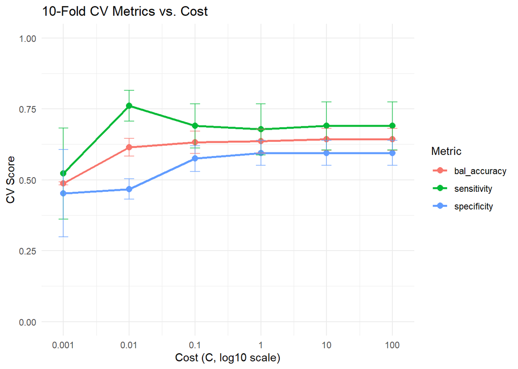

```r
collect_metrics(lin_res) |>
  ggplot(aes(x = cost, y = mean, color = .metric)) +
  geom_line(linewidth = 1) +
  geom_point(size = 2.5) +
  geom_errorbar(
    aes(ymin = mean - std_err, ymax = mean + std_err),
    width = 0.15,
    alpha = 0.7
  ) +
  scale_x_log10(
    breaks = 10^(-3:2),
    labels = scales::label_number(drop0trailing = TRUE)
  ) +
  scale_y_continuous(limits = c(0, 1)) +
  labs(
    title = "10-Fold CV Metrics vs. Cost",
    x = "Cost (C, log10 scale)",
    y = "CV Score",
    color = "Metric"
  ) +
  theme_minimal()
```

> **Q2.** Why does the unweighted SVM predict “no” for every sample at every C? (Hint: write down the total slack Σξᵢ of the constant classifier β = 0, β₀ = −1, and think about how much any hyperplane could reduce it when the classes overlap this much.) What do the class weights change? How does the number of support vectors change with C, and why? Is C in `ksvm` the same as C in ISL Chapter 9? Why does the fit stop changing above C = 1? Which predictors have the largest coefficients toward exceedance, and why should you not read the signs of the four `APD` lags as separate effects?

The unweighted SVM predicts “no” for every sample at every C because the SVM pushes the hyperplane far into the “yes” prediction in order to minimize total penalty, which is a problem because there are not many “yes” predictions. Class weights assign separate penalities to each class to reduce class imbalance. The number of support vectors decreases as C increases because C controls the width of the margin. With a small C, there is a wide margin, which will include more support vectors, and viceversa. C in ‘ksvm’ is the same as ISL chapter 9 (the budget for the amount that the margin can be violated). The fit stops changing above C = 1 because at C = 1, every training point lies on or outside the margin. Lograin6, APD2, PD3, and tide_max4 have hte largest coefficients. You should not read the signs of the APD lags as separate effects because these predictors are heavily collinear.

## 3.3 Part C — Polynomial and radial kernels (slides: SVM with non-linear kernels)

6. With class weights, tune a polynomial SVM over C ∈ {0.01, 0.1, 1, 10, 100} × degree ∈ {2, 3} × scale_factor ∈ {0.01, 0.1, 1}, and a radial SVM over C ∈ {0.01, …, 100} × σ ∈ {0.001, 0.01, 0.1, 1}. Use the same folds and balanced accuracy. Draw a heatmap of CV balanced accuracy over C × σ for the radial kernel.

```r
# ---- Part C ------------------------------------------------------------------

# polynomial SVM
poly_spec <- svm_poly(cost = tune(),degree = tune(),scale_factor = tune()) |>
  set_engine("kernlab", class.weights = w_bal, prob.model = FALSE) |>
  set_mode("classification")

poly_grid <- crossing(
  cost = 10^(-2:2),
  degree = c(2, 3),
  scale_factor = 10^(-2:0)
)

poly_res <- tune_grid(workflow(rec, poly_spec),resamples = folds,grid = poly_grid,metrics = cv_metrics)

# radial SVM
rbf_spec <- svm_rbf(cost = tune(), rbf_sigma = tune()) |>
  set_engine("kernlab", class.weights = w_bal, prob.model = FALSE) |>
  set_mode("classification")
rbf_res <- tune_grid(workflow(rec, rbf_spec), resamples = folds,
                     grid = crossing(cost = 10^(-2:2), rbf_sigma = 10^(-3:0)),
                     metrics = cv_metrics)                            # ~15 s; poly ~1 min

# best models
show_best(lin_res, metric = "bal_accuracy", n = 5)
```

```
## # A tibble: 5 × 7
##     cost .metric      .estimator  mean     n std_err .config
##    <dbl> <chr>        <chr>      <dbl> <int>   <dbl> <chr>
## 1  10    bal_accuracy binary     0.642    10  0.0388 pre0_mod5_post0
## 2 100    bal_accuracy binary     0.642    10  0.0388 pre0_mod6_post0
## 3   1    bal_accuracy binary     0.636    10  0.0423 pre0_mod4_post0
## 4   0.1  bal_accuracy binary     0.633    10  0.0394 pre0_mod3_post0
## 5   0.01 bal_accuracy binary     0.614    10  0.0315 pre0_mod2_post0
```

```r
show_best(poly_res, metric = "bal_accuracy", n = 5)
```

```
## # A tibble: 5 × 9
##    cost degree scale_factor .metric      .estimator  mean     n std_err .config
##   <dbl>  <dbl>        <dbl> <chr>        <chr>      <dbl> <int>   <dbl> <chr>
## 1     1      3         0.01 bal_accuracy binary     0.643    10  0.0337 pre0_mo…
## 2    10      2         0.01 bal_accuracy binary     0.634    10  0.0437 pre0_mo…
## 3     1      2         0.01 bal_accuracy binary     0.630    10  0.0318 pre0_mo…
## 4   100      2         0.01 bal_accuracy binary     0.628    10  0.0330 pre0_mo…
## 5     1      2         0.1  bal_accuracy binary     0.626    10  0.0312 pre0_mo…
```

```r
show_best(rbf_res, metric = "bal_accuracy", n = 5)
```

```
## # A tibble: 5 × 8
##    cost rbf_sigma .metric      .estimator  mean     n std_err .config
##   <dbl>     <dbl> <chr>        <chr>      <dbl> <int>   <dbl> <chr>
## 1   0.1     0.1   bal_accuracy binary     0.634    10  0.0333 pre0_mod07_post0
## 2   1       0.01  bal_accuracy binary     0.632    10  0.0348 pre0_mod10_post0
## 3  10       0.001 bal_accuracy binary     0.630    10  0.0293 pre0_mod13_post0
## 4 100       0.001 bal_accuracy binary     0.630    10  0.0382 pre0_mod17_post0
## 5 100       0.01  bal_accuracy binary     0.609    10  0.0398 pre0_mod18_post0
```

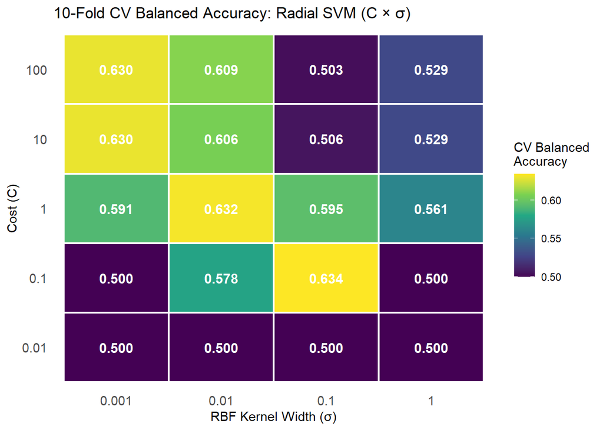

```r
# heatmap
rbf_res |>
  collect_metrics() |>
  filter(.metric == "bal_accuracy") |>
  ggplot(aes(x = factor(rbf_sigma), y = factor(cost), fill = mean)) +
  geom_tile(color = "white", linewidth = 0.8) +
  geom_text(aes(label = sprintf("%.3f", mean)), color = "white", fontface = "bold", size = 4) +
  scale_fill_viridis_c(option = "viridis", name = "CV Balanced\nAccuracy") +
  labs(
    title = "10-Fold CV Balanced Accuracy: Radial SVM (C × σ)",
    x = "RBF Kernel Width (σ)",
    y = "Cost (C)"
  ) +
  theme_minimal() +
  theme(
    panel.grid = element_blank(),
    axis.text = element_text(size = 11)
  )
```

7. Finalise the best setting of each kernel (linear, polynomial, radial), fit on all training data, and make one test-set table with the number of support vectors, CV balanced accuracy, and test sensitivity, specificity, balanced accuracy, accuracy, AUC and number of days flagged. Compute AUC from the decision value (`svm_score()`), not from a probability.

```r
# fit best model
lin_fit_best <- finalize_workflow(workflow(rec, lin_spec), select_best(lin_res, metric = "bal_accuracy")) |> fit(train)

poly_fit_best <- finalize_workflow(workflow(rec, poly_spec),select_best(poly_res, metric = "bal_accuracy")) |> fit(train)

rbf_fit_best <- finalize_workflow(workflow(rec, rbf_spec),select_best(rbf_res, metric = "bal_accuracy")) |> fit(train)

# extract all CV + test-set metrics for one kernel
eval_kernel <- function(kernel_name, wf_fit, tune_res) {

  best_cv_bal <- show_best(tune_res, metric = "bal_accuracy", n = 1)$mean


  test_preds <- bind_cols(
    test |> select(exc),
    predict(wf_fit, test)
  )
  scores <- svm_score(wf_fit, test)

  tibble(
    kernel        = kernel_name,
    nSV           = kernlab::nSV(extract_fit_engine(wf_fit)),
    cv_bal_acc    = best_cv_bal,
    test_sens     = sens(test_preds, truth = exc, estimate = .pred_class)$.estimate,
    test_spec     = spec(test_preds, truth = exc, estimate = .pred_class)$.estimate,
    test_bal_acc  = bal_accuracy(test_preds, truth = exc, estimate = .pred_class)$.estimate,
    test_accuracy = accuracy(test_preds, truth = exc, estimate = .pred_class)$.estimate,
    test_auc      = roc_auc_vec(test$exc, scores),
    days_flagged  = sum(test_preds$.pred_class == "yes")
  )
}

test_comparison <- bind_rows(
  eval_kernel("Linear",     lin_fit_best,  lin_res),
  eval_kernel("Polynomial", poly_fit_best, poly_res),
  eval_kernel("Radial",     rbf_fit_best,  rbf_res)
)

print(test_comparison)
```

```
## # A tibble: 3 × 9
##   kernel       nSV cv_bal_acc test_sens test_spec test_bal_acc test_accuracy
##   <chr>      <int>      <dbl>     <dbl>     <dbl>        <dbl>         <dbl>
## 1 Linear       221      0.642      0.65     0.649        0.649         0.649
## 2 Polynomial   240      0.643      0.75     0.622        0.686         0.649
## 3 Radial       278      0.634      0.65     0.676        0.663         0.670
## # ℹ 2 more variables: test_auc <dbl>, days_flagged <int>
```

8. Draw 2,000 stratified bootstrap resamples of the test set. Report a 95% interval for each kernel’s test AUC and for the AUC differences polynomial − linear and radial − linear.

```r
# decision values on the test set
test_scores <- tibble(
  exc  = test$exc,
  lin  = svm_score(lin_fit_best, test),
  poly = svm_score(poly_fit_best, test),
  rbf  = svm_score(rbf_fit_best, test)
)


# bootstrap resamples
set.seed(1234)
boot_splits <- bootstraps(test_scores, times = 2000, strata = exc)

# AUCs
boot_aucs <- map_dfr(boot_splits$splits, function(split) {
  d <- analysis(split)

  auc_lin  <- roc_auc_vec(d$exc, d$lin)
  auc_poly <- roc_auc_vec(d$exc, d$poly)
  auc_rbf  <- roc_auc_vec(d$exc, d$rbf)

  tibble(
    Linear             = auc_lin,
    Polynomial         = auc_poly,
    Radial             = auc_rbf,
    `Polynomial - Linear` = auc_poly - auc_lin,
    `Radial - Linear`     = auc_rbf - auc_lin
  )
})


# point estimates and 95% CIs
point_ests <- tibble(
  metric = c("Linear", "Polynomial", "Radial", "Polynomial - Linear", "Radial - Linear"),
  estimate = c(
    roc_auc_vec(test_scores$exc, test_scores$lin),
    roc_auc_vec(test_scores$exc, test_scores$poly),
    roc_auc_vec(test_scores$exc, test_scores$rbf),
    roc_auc_vec(test_scores$exc, test_scores$poly) - roc_auc_vec(test_scores$exc, test_scores$lin),
    roc_auc_vec(test_scores$exc, test_scores$rbf)  - roc_auc_vec(test_scores$exc, test_scores$lin)
  )
)

boot_summary <- boot_aucs |>
  pivot_longer(everything(), names_to = "metric", values_to = "val") |>
  group_by(metric) |>
  summarize(
    ci_lower = quantile(val, 0.025),
    ci_upper = quantile(val, 0.975),
    .groups = "drop"
  ) |>
  right_join(point_ests, by = "metric") |>
  select(metric, estimate, ci_lower, ci_upper)

print(boot_summary)
```

```
## # A tibble: 5 × 4
##   metric              estimate ci_lower ci_upper
##   <chr>                  <dbl>    <dbl>    <dbl>
## 1 Linear               0.748     0.635    0.848
## 2 Polynomial           0.751     0.636    0.852
## 3 Polynomial - Linear  0.00270  -0.0189   0.0236
## 4 Radial               0.730     0.603    0.837
## 5 Radial - Linear     -0.0182   -0.0676   0.0304
```

The polynomial kernal has the highest balanced accuracy and highest AUC. In the best polynomial model, there is a cost of 1, degree of 3, and scale factor of 0.01. It is at the edge of the grid for degree and scale factor, but not for cost. When scale is small, the equation gets smaller. The radial heatmap shows that at a high cost, a low sigma provides a balanced accuracy, and with a higher sigma, a lower cost provides a better balanced accuracy. Every C = 0.01 cell scores exactly 0.5 because when C is small, there will only be one class prediction for each observation, so sensitivity will be 1 or 0 and specificity will be 0 or 1, giving a balanced accuracy value of 0.5 every time. The non-linear kernals do not beat the linear kernal, as evidenced by 0 being contained within the 95% confidence interval in the paired AUC differences, on the test set. Most training samples being support vectors indicates a very wide margin. The test AUCs are higher than table S7 and table S8.

## 3.4 Part D — Scores, probabilities and the cutoff (SI Tuning Case Study)

9. Refit each tuned model **without class weights** and with `prob.model = TRUE`, so kernlab adds Platt-scaled probabilities. On the test set, count the predicted classes that are “yes” and the probabilities above 0.5, and report the maximum and mean probability. Compare the AUC from the probability with the AUC from `svm_score()`.

```r
# refit and calculate metrics foreach kernal type
eval_platt <- function(kernel_name, base_spec, tune_res) {
  prob_spec <- finalize_model(base_spec, select_best(tune_res, metric = "bal_accuracy")) |>
    set_engine("kernlab", prob.model = TRUE)

  set.seed(1234)
  prob_fit <- workflow(rec, prob_spec) |> fit(train)

  pred_cls  <- predict(prob_fit, test, type = "class")$.pred_class
  pred_prob <- predict(prob_fit, test, type = "prob")$.pred_yes
  scores    <- svm_score(prob_fit, test)

  tibble(
    kernel        = kernel_name,
    pred_yes      = sum(pred_cls == "yes"),
    prob_gt_05    = sum(pred_prob > 0.5),
    max_prob      = max(pred_prob),
    mean_prob     = mean(pred_prob),
    auc_from_prob = roc_auc_vec(test$exc, pred_prob),
    auc_from_score = roc_auc_vec(test$exc, scores)
  )
}

platt_results <- bind_rows(
  eval_platt("Linear",     lin_spec,  lin_res),
  eval_platt("Polynomial", poly_spec, poly_res),
  eval_platt("Radial",     rbf_spec,  rbf_res)
)

print(platt_results)
```

```
## # A tibble: 3 × 7
##   kernel     pred_yes prob_gt_05 max_prob mean_prob auc_from_prob auc_from_score
##   <chr>         <int>      <int>    <dbl>     <dbl>         <dbl>          <dbl>
## 1 Linear            0          0    0.292     0.292         0.738          0.738
## 2 Polynomial        0          0    0.356     0.285         0.698          0.698
## 3 Radial            0          2    0.632     0.279         0.691          0.691
```

10. Refit the tuned **radial** model **with** class weights and `prob.model = TRUE`. Compute the *training* AUC from `.pred_yes` and from `svm_score()`, and their correlation.

```r
rbf_w_prob_spec <- finalize_model(
  rbf_spec,
  select_best(rbf_res, metric = "bal_accuracy")
) |>
  set_engine("kernlab", class.weights = w_bal, prob.model = TRUE)

set.seed(1234)
rbf_w_prob_fit <- workflow(rec, rbf_w_prob_spec) |> fit(train)

# training Platt probabilities and raw decision values
train_prob_yes <- predict(rbf_w_prob_fit, train, type = "prob")$.pred_yes
train_score    <- svm_score(rbf_w_prob_fit, train)

# training AUCs and correlation
train_auc_prob  <- roc_auc_vec(train$exc, train_prob_yes)
train_auc_score <- roc_auc_vec(train$exc, train_score)
cor_pearson     <- cor(train_prob_yes, train_score, method = "pearson")
cor_spearman    <- cor(train_prob_yes, train_score, method = "spearman")

tibble(
  train_auc_prob  = train_auc_prob,
  train_auc_score = train_auc_score,
  pearson_cor     = cor_pearson,
  spearman_cor    = cor_spearman
)
```

```
## # A tibble: 1 × 4
##   train_auc_prob train_auc_score pearson_cor spearman_cor
##            <dbl>           <dbl>       <dbl>        <dbl>
## 1          0.259           0.741      -0.995           -1
```

11. Apply the paper’s cutoff rule: the cutoff on the decision value with the highest sensitivity subject to specificity ≥ 0.80 (`cut_at_spec()`). Choose it (a) on the training-set scores, as the paper did, and (b) on out-of-fold CV scores (`oof_scores()`). Apply each cutoff, and the default (score > 0), to the test set. Report sensitivity, specificity and the share of days flagged, along with the training and out-of-fold AUCs.

```r
# the paper's rule: lowest cutoff with specificity >= 0.80 (= highest sensitivity)
cut_at_spec <- function(score, truth, min_spec = 0.80) {
  neg <- sort(score[truth == "no"])
  neg[ceiling(min_spec * length(neg))]
}

oof_scores <- function(wf, folds) {
  map(folds$splits, \(s) {
    f <- fit(wf, analysis(s)); a <- assessment(s)
    tibble(.row = as.integer(s, data = "assessment"), exc = a$exc, score = svm_score(f, a))
  }) |> list_rbind() |> arrange(.row)
}

rbf_wf <- finalize_workflow(workflow(rec, rbf_spec),
                            select_best(rbf_res, metric = "bal_accuracy"))
oof <- oof_scores(rbf_wf, folds)
cut_oof <- cut_at_spec(oof$score, oof$exc)

rbf_fit     <- fit(rbf_wf, train)
train_score <- svm_score(rbf_fit, train)
test_score  <- svm_score(rbf_fit, test)

# training cut off vs out of fold cutoff
cut_train <- cut_at_spec(train_score, train$exc)

# training and out of fold CVs
c(
  train_auc = roc_auc_vec(train$exc, train_score),
  oof_auc   = roc_auc_vec(oof$exc, oof$score)
)
```

```
## train_auc   oof_auc
## 0.7413486 0.6782209
```

```r
# apply to test scre
eval_cut <- function(name, cut) {
  pred <- factor(ifelse(test_score > cut, "yes", "no"), levels = levels(test$exc))
  tibble(
    rule          = name,
    cutoff        = cut,
    test_sens     = sens_vec(test$exc, pred),
    test_spec     = spec_vec(test$exc, pred),
    share_flagged = mean(pred == "yes")
  )
}

bind_rows(
  eval_cut("Default (score > 0)", 0),
  eval_cut("(a) Train cutoff",    cut_train),
  eval_cut("(b) OOF cutoff",      cut_oof)
)
```

```
## # A tibble: 3 × 5
##   rule                cutoff test_sens test_spec share_flagged
##   <chr>                <dbl>     <dbl>     <dbl>         <dbl>
## 1 Default (score > 0)  0          0.65     0.676         0.394
## 2 (a) Train cutoff     0.221      0.5      0.784         0.277
## 3 (b) OOF cutoff       0.261      0.45     0.824         0.234
```

> **Q4.** What does an SVM output, and what does Platt scaling do to it? Why can it not change the AUC? Using your answer to Task 9, explain the SVM row of Table S7 (sensitivity 0.00, specificity 1.00). The paper used balanced class weights and still got that result; read how `beach_model.py` makes its predictions (`predict_proba(...)[:, 1]`, then `> 0.5`) and explain why. What went wrong in Task 10, and what check would have caught it? Compare your tuned-cutoff results with the paper’s tuned SVMs (sensitivity 0.32, specificity 0.78). Which cutoff would you give a beach manager, and why should the cutoff be chosen on out-of-fold rather than training scores?

Platt scaling adds a curve over the decision value. It cannot chance the AUC because the AUC depends on the rank ordering of the predictions, which stay the same with the Platt scaling. The SVM row of table S7 has a specificity of 1 and a sensitivity of 0 because when the probability threshold is greater than 0.5, zero days cross this because the dataset is imbalanced. The paper still got this result even after using balanced class weights because the Platt scaling undoes the class weights. In task 10, the correlation is almost -1, and checking this correlation right after fitting the models would have caught this. The tuned cutoff results give a sensitivity of between 0.45 and 0.65, which is higher than the paper, and a specificity between 0.67 and 0.82, which is on par with the paper. I would give a beach manager a cutoff of 0.26 because this cutoff has a high specificity, meaning there will be few unnecessary beach closures. The cutoff should be chosen from the out of fold because using the training cutoff may overfit the data.

## 3.5 Part E — Interpretation

> **Q5.** (a) Your test AUC is well above the paper’s medians. Give at least two reasons that do not involve your SVM being better. Think about how the 10 predictors were chosen (Table S6 summarises models from all eight partitions), about Table S5, and about the uncertainty from Task 8. (b) What does a train-2007–2012, test-2013–2014 split test that 10-fold CV within 2007–2012 does not? (c) At the paper’s cutoff, about what share of flagged days really exceed? Would this be useful as an early warning, compared with posting from last week’s sample? (d) What share of samples followed rain, and what does that imply for using a model like this to study extreme precipitation and waterborne illness? What data would you need instead?

One reason why the test AUC might be above the paper’s medians is because the use of bootstrapped samples may lead to slightly different results each time. A second reason is because the predictors are collinear. The train-2007-2012, test-2013-2014 split tests the implementation of the water quality infrastructure that is not captured within the 10-fold CV within 2007-2012. At the paper’s cutoff, about 0.39 of the flagged days exceed. This may be useful as an early warning, though the moderate sensitivities indicate that public health risks may be missed. 28/290 samples followed rain. This implies that other variables will be needed to study extreme precipitation and waterborne illness, such as treatment infrastructure, pollution sources, permeability of surface, and soil mositure, among other factors.

# 4 Starter code

```r
library(tidyverse)
library(tidymodels)
library(kernlab)
tidymodels_prefer()

cb <- read_csv("cowell_ec_lead1.csv") |>
  mutate(exc = factor(if_else(EC_exc == 1, "yes", "no"), levels = c("yes", "no")))
predictors <- c("lograin6", "logflow4", "WVHT4", "APD2", "APD3", "APD4", "APD5",
                "tide_max4", "rad4", "atemp_min5")
train <- cb |> filter(split == "train") |> select(exc, all_of(predictors))
test  <- cb |> filter(split == "test")  |> select(exc, all_of(predictors))

# the paper's class_weight = 'balanced': n / (2 * n_class)
w_bal <- c(yes = nrow(train) / (2 * sum(train$exc == "yes")),
           no  = nrow(train) / (2 * sum(train$exc == "no")))

rec <- recipe(exc ~ ., data = train) |> step_normalize(all_predictors())

# ---- helpers -----------------------------------------------------------------
# SVM decision value f(x), oriented so that larger = more likely "yes".
# (kernlab's decision value is positive for the 2nd factor level, "no", so we flip it.)
svm_score <- function(wf_fit, new_data) {
  x <- extract_recipe(wf_fit) |> bake(new_data = new_data, all_predictors())
  -as.numeric(predict(extract_fit_engine(wf_fit), x, type = "decision"))
}
# linear kernel only: coefficient vector beta (standardized scale), positive = toward "yes"
svm_w <- function(wf_fit) {
  m <- extract_fit_engine(wf_fit)
  -colSums(coef(m)[[1]] * xmatrix(m)[[1]])
}
# prob.model = FALSE: no Platt probabilities (see Part D), so predict() returns classes only
lin_fit <- function(C, weights = NULL, data = train) {
  spec <- svm_linear(cost = C) |>
    set_engine("kernlab", class.weights = weights, prob.model = FALSE) |>
    set_mode("classification")
  workflow(rec, spec) |> fit(data)
}

# ---- Part B ------------------------------------------------------------------
f <- lin_fit(1)                                       # unweighted
nSV(extract_fit_engine(f)); sqrt(sum(svm_w(f)^2))
table(predict(f, train)$.pred_class)

set.seed(1234)
folds <- vfold_cv(train, v = 10, strata = exc)        # reuse these folds in Parts C and D
cv_metrics <- metric_set(bal_accuracy, sensitivity, specificity)
lin_spec <- svm_linear(cost = tune()) |>
  set_engine("kernlab", class.weights = w_bal, prob.model = FALSE) |>
  set_mode("classification")
lin_res <- tune_grid(workflow(rec, lin_spec), resamples = folds,
                     grid = tibble(cost = 10^(-3:2)), metrics = cv_metrics)
collect_metrics(lin_res)

# ---- Part C ------------------------------------------------------------------
rbf_spec <- svm_rbf(cost = tune(), rbf_sigma = tune()) |>
  set_engine("kernlab", class.weights = w_bal, prob.model = FALSE) |>
  set_mode("classification")
rbf_res <- tune_grid(workflow(rec, rbf_spec), resamples = folds,
                     grid = crossing(cost = 10^(-2:2), rbf_sigma = 10^(-3:0)),
                     metrics = cv_metrics)                            # ~15 s; poly ~1 min
rbf_fit <- finalize_workflow(workflow(rec, rbf_spec), select_best(rbf_res, metric = "bal_accuracy")) |>
  fit(train)
roc_auc_vec(test$exc, svm_score(rbf_fit, test))       # AUC from the decision value

# ---- Part D ------------------------------------------------------------------
# Platt probabilities: same model, prob.model = TRUE (drop class.weights for Task 9)
rbf_prob_spec <- finalize_model(rbf_spec, select_best(rbf_res, metric = "bal_accuracy")) |>
  set_engine("kernlab", prob.model = TRUE)
set.seed(1234)
rbf_prob <- workflow(rec, rbf_prob_spec) |> fit(train)
predict(rbf_prob, test, type = "prob")

# the paper's rule: lowest cutoff with specificity >= 0.80 (= highest sensitivity)
cut_at_spec <- function(score, truth, min_spec = 0.80) {
  neg <- sort(score[truth == "no"])
  neg[ceiling(min_spec * length(neg))]                # predict "yes" when score > cutoff
}
# out-of-fold decision values: each training sample scored by a model fitted without it
oof_scores <- function(wf, folds) {
  map(folds$splits, \(s) {
    f <- fit(wf, analysis(s)); a <- assessment(s)
    tibble(.row = as.integer(s, data = "assessment"), exc = a$exc, score = svm_score(f, a))
  }) |> list_rbind() |> arrange(.row)
}
oof <- oof_scores(finalize_workflow(workflow(rec, rbf_spec),
                                    select_best(rbf_res, metric = "bal_accuracy")), folds)
cut_at_spec(oof$score, oof$exc)
```

**Warnings you can ignore.** kernlab prints `maximum number of iterations reached` and `line search fails` while it fits Platt probabilities (Part D). These come from its internal logistic fit and do not stop anything.

# 5 Check your numbers

- **Part A:** 290 training samples with 85 exceedances, and 94 test samples with 20. “Always no” scores 0.787 on the test set. About 11% of samples had rain 6 days before.
- **Part B:** the unweighted fits have ‖β‖ < 0.001 and predict no “yes” at all. With class weights at C = 1: 221 support vectors, training sensitivity ≈ 0.73, specificity ≈ 0.60. CV balanced accuracy is ≈ 0.63–0.64 for every C ≥ 0.1.
- **Part C:** CV balanced accuracy for the best setting of each kernel is ≈ 0.63–0.64. Test AUC is ≈ 0.73–0.75 for all three kernels.
- **Part D:** without class weights, almost no test probability exceeds 0.5. The paper’s cutoff rule gives test specificity ≈ 0.78–0.84.
- **Runtime:** about 2 minutes for everything. The polynomial grid is the slowest part (≈ 1 min). Results can differ slightly from the key with other package versions.